# Statistical_Rethinking_RM

SM

2024-01-16

# 1 Chapter 1: The Golem of Prague

$~$

Chapter 1 urged us to rethink the “popular statistical and scientific philosophy” by pointing out the flaws in classical statistical tools and reasoning.

According to the author, “classical tools are not diverse enough to handle many common research questions…And if we keep adding new types of tools, soon there will be far too many to keep track of.” I agree with these statements. The author also talked about how Fisher’s exact test is used “whenever the cell counts are small” and he had “never seen it used appropriately” except Fisher’s original use of the test. It would be nice if the author gave some examples and explanations of those inappropriate uses- I can’t decide whether to accept without more information.

The author mentioned why deductive falsification is impossible in scientific context:

1. “Hypotheses are not models. The relations among hypotheses and different kinds of models are complex. Many models correspond to the same hypothesis, and many hypotheses correspond to a single model. This makes strict falsification impossible.
2. Measurement matters. Even when we think the data falsify a model, another observer will debate our methods and measures. They don’t trust the data. Sometimes they are right.

For both of these reasons, deductive falsification never works. The scientific method cannot be reduced to a statistical procedure, and so our statistical methods should not pretend.”

$~$

## 1.1 Hypotheses are not models

He gave an example of the first statement in evolutionary context. His conclusion was:

1. “Any given statistical model (M) may correspond to more than one process model (P).
2. Any given hypothesis (H) may correspond to more than one process model (P).
3. Any given statistical model (M) may correspond to more than one hypothesis (H).”

In other words, it doesn’t matter whether we reject or fail to reject the null. It won’t have “much inferential power” or give any useful insights due to possible existence of models- other than the ones under study- which can also align with the null or alternative hypotheses. The author gave a solution to this dilemma- “explicitly compare predictions of more than one model.” This is a very nice solution, as I think it will allow analysis of hypothesis or whatever you want to study in real-world conditions. And that is much more powerful than any classical tests.

In that case, should we disregard all studies that rely on NHST? Should we reject all findings made by rejecting the null hypothesis as senseless? And are the multiple process models the only way to go? The frequentists’ way to solve this problem is to control the conditions of the experiment/study. In nutrition studies, this can be in the form of inclusion or exclusion criteria and strict control of test subjects (and conditions) throughout the duration of the study. This is to ensure the observed effect (or lack of) is caused by (or related to) the variables of interest and not by uncontrolled confounders. If a NHST research was done well with proper control, then we could ‘more or less’ have confidence in the research’s findings.

$~$

## 1.2 *Measurement matters*

In the section “measurement matters,” the author reinforced the first statement, and explained the fallacy of falsification principle, stating two reasons:

1. “Observations are prone to error, especially at the boundaries of scientific knowledge.
2. Most hypotheses are quantitative, concerning the degrees of existence, rather than discrete, concerning total presence or absence.”

### 1.2.1 *Observation error*

The author gave two examples of observation error. The first example pointed out possible bias or errors in observations, and potential type 1 and type 2 errors (false positives and false negatives) in classical frequentist researches. And the second example talked about errors in measurements (or studies/ experiments). Both are valid concerns and those errors are not uncommon in frequentist researches.

There are several ways to overcome these shortcomings, depending on research design. For example, we can increase sample size or run more tests to reduce type 1 and type 2 errors. Errors in measurements can be avoided by following protocols- taking at least two measurements for each sample, consistency in measurements, etc. However, there is no guarantee that any particular researcher or research group will follow a strict protocol without compromising, and that can lead to observation error. To prevent this, we usually avoid using finding from a single research, and wait till the findings are backed by systematic reviews and made into guidelines.

In both woodpecker and neutrino examples, the author’s key concerns were “whether falsification is real or spurious,” and that “both true-detection and false-detection plausible.” The null hypothesis in the woodpecker example was “The Ivory-billed Woodpecker is extinct.” According to the author, it will only take a single woodpecker to falsify this theory, and that the 2005 evidence on existence of a woodpecker was doubted by many. Since no other evidences emerged, the question remained unresolved. That means finding was not conclusive yet, and research was still ongoing. As I mentioned above, we don’t accept findings from a single research as concrete or irrefutable evidence. Thus, the dilemma over falsification and type 1 or type 2 error in the woodpecker case was not really a concern- we would just need to conduct more surveys (wider location for longer period?) or simply wait for new evidences. However, I think this is not a good case to use the null hypothesis testing. The falsification of hypothesis in this case will be simply the result of patience or luck, rather than proper research design or statistical tests. In the neutrino example, the problem was the human error which they solved by replication of experiments. This is not unusual in frequentist research. Replicating or reconducting experiment is a common occurrence, especially when lab analyses are involved. It may be an inconvenience, but it does not imply the utter failure of the theory of falsification or the null hypothesis testing.

### 1.2.2 *Continuous hypotheses*

The author noted “…it is a good practice to design experiments and observations that can differentiate competing hypotheses. But in many cases, the comparison must be probabilistic, a matter of degree, not kind.” Two examples of null hypotheses that support the above statement were given: “80% of swans are white” and “Black swans are rare.” The author pointed out the *modus tollens* swan story would not be applicable in this case, since the problem is not to prove or disprove the hypothesis but to estimate the distribution of swan coloration. He added “You might object that the hypothesis above is just not a good scientific hypothesis, because it isn’t easy to disprove. But if that’s the case, then most of the important questions about the world are not good scientific hypotheses.”

In my opinion, it is not difficult to disprove both hypotheses. The two hypothese are not good hypotheses simply because they are not specific and fail to form sensible research question or outcome- not because it is “a matter of degree.” Let’s break down the two hypotheses. First, we think about the possible research question for the hypothesis “80% of swan are white.” The research question could be “Are 80% of swan white?” or “Do 80% of swan have white feathers?” In this case, this hypothesis would be disprove if survey found any percent of white swan other than 80%. It wouldn’t matter if the actual percent was 90 or 95- we could stop the research once the number passed the threshold of 80%. Now it is clear that the problem with this hypothesis is the pointless outcome. What are we trying to achieve knowing whether 80% of swan are white, or 40% or any percentage of swan are white in color? A more sensible hypothesis would be “White coloration is the dominant trait in swan.” We can falsify this hypothesis by conducting surveys- like the author suggested- or genetic analysis, etc. Still, it is not a good hypothesis for an original research since the scope is too broad. The hypothesis only specify swan- not a particular speices or geographical location, meaning all swan species in the world are included in the research. That would be a hard task for any single researcher or research group. Hence, this hypothesis is more suitable at review level- not original research level. For original research, we can specify the species of swan and extent of study area based on the available funding.

The second hypothesis “Black swans are rare” has the similar problem- lack of specificity. We need to determine what is considered rare- 1 in 100 or 1 in a million? Once we have that specification, it is not difficult to tackle the second hypothesis. But we need to be aware that the second hypothesis also includes all swan species in the world- or even universe or parallel universes.

Another thing is the *modus tollens* swan story was merely to explain a theory- not a definitive example of how we should write hypothesis. I have yet to see a research with hypothesis written like the one in *modus tollens* swan story. All hypotheses that I have seen so far address “the degree, not kind”-like the author suggested. Hence, the author’s concern over hypotheses is somehow invalid.

### 1.2.3 *Falsification is consensual*

The author said “falsification is always consensual, not logical,” and “evidence often— but not always— has something to do with such falsification.” He also highlighted the arguments towards “consensus about meaning of evidence” and the danger of “historical revisionism.” I think the author is right. We hold such reverence towards the famous scientists in history, that their formulas are still widely applied to this day, without contesting their suitability in this age. Many researches were done following the same mould, that they gave similar results, which became our gold-standard- the guidelines. And those guidelines are not set in stone. They are regularly updated- albeit minor changes. Occasionally, some guidelines are completely proven false and replaced by new ones. These occasions are rare that they are called groundbreaking discovery. I remembered the day everyone at the department was talking about the guideline change on egg consumption- may seem insignificant to outsiders but we were really excited! It could be that such new discoveries are rare because we are doing the same thing over and over again, and are content when our findings (even vaguely) agree the current consensus- we seek validation from previous works by researchers more venerable than us. And that is dangerous to our patients and the public. We may be feeling relaxed because we think the worst that can happen from such findings is “the treatment is ineffective but not harmful.” We pour scorn on some of the treatments given by the healthcare providers some hundred years ago as harmful and ineffective. We can do so because we now have the knowledge collected over time. It is very possible our best guidelines may seem ‘folly’ to the researchers in the next hundred years. Thus, I agree with the author that it’s time we should do things differently.

$~$

## 1.3 Three tools for golem engineering

The author gave alternative to falsification- that is to build models. According to the author, “Models can be made into testing procedures— all statistical tests are also models—but they can also be used to measure, forecast, and argue.” He also mentioned three models that are “in demand in both the social and biological sciences.”

1. Bayesian data analysis
2. Multilevel models
3. Model comparison using information criteria

### 1.3.1 *Bayesian data analysis*

As explained by the author, Bayesian data analysis uses uncertainty or chance to “describe plausibility of different possibilities,” and “…we can use probability theory as a general way to represent plausibility, whether in reference to countable events in the world or rather theoretical constructs like parameters.” The author then compared this approach to frequentist approach- “Bayesian probability is a very general approach to probability…The frequentist approach requires that all probabilities be defined by connection to countable events and their frequencies in very large samples.” And the author pointed out “…This leads to frequentist uncertainty being premised on imaginary resampling of data— if we were to repeat the measurement many many times, we would end up collecting a list of values that will have some pattern to it. It means also that parameters and models cannot have probability distributions, only measurements can. The distribution of these measurements is called a sampling distribution. This resampling is never done, and in general it doesn’t even make sense…”

He also quoted “one of the most important frequentist statisticians of the 20<sup>th</sup> century,” Sir Ronald Fisher:

“[…] the only populations that can be referred to in a test of significance have no objective reality, being exclusively the product of the statistician’s imagination […]”

But, Fisher’s criticism was already rebuked by his contemporary Professor Egon Pearson in his [“Statistical Concepts in Their Relation to Reality”](https://errorstatistics.files.wordpress.com/2021/02/pearson_1955-stat-concepts-reality.pdf). Pearson said:

“…If probability is to be justly applied to the analysis of data, it follows that a random process must have been introduced or been naturally present at some stage in the collection of these data. Is there not then an appeal to the imagination in taking as the hypothetical population of samples that which would have been generated by repetition of this random process?…”

According to Pearson, Fisher was “often tilting at views which those whom he attacks have never held.” And I can use Pearson’s argument to address the “telescope” example given by the author.

“…Since the telescope was primitive, it couldn’t really focus the image very well. Saturn always appeared blurred. This is a statistical problem, of a sort. There’s uncertainty about the planet’s shape, but notice that none of the uncertainty is a result of variation in repeat measurements. We could look through the telescope a thousand times, and it will always give the same blurred image (for any given position of the Earth and Saturn). So the sampling distribution of any measurement is constant, because the measurement is deterministic— there’s nothing “random” about it. Frequentist statistical inference has a lot of trouble getting started here…”

I think, like Fisher, the author is also “tilting at views” which frequentists have never held. The problem with the telescope example is that repeated measurements were done on “ONE” sample only. That’s why he made assumption that “…none of the uncertainty is a result of variation in repeat measurements…So the sampling distribution of any measurement is constant, because the measurement is deterministic— there’s nothing “random” about it.” I have yet to see a research that only measures “one” sample repeatedly to solve a research question at population level or in real-world situations. It would be akin to asking a single child- using different sets of questions- repeatedly about what the child eats in a day to know the dietary pattern of all the children in the region. It makes no sense. Furthermore, sample representativeness play a major role in such researches. The author representation of a frequentist research has no place for sample representativeness- there is only one sample and nothing else.

The author also criticized about “imagined repeat sampling.” If taken out of context, such idea can be quite preposterous. But, it can actually be logical if we explain it in terms of sample representativeness. We are not imagining repeated sampling- beyond our chosen sample sets- to justify the results from our samples are applicable to the population. For example, if we were to study the dietary pattern of an ethnic group reside in the mountain, we do not need to ask dietary-related questions to every individual in the group. We select a fraction of the group- chosen at random- to infer the dietary pattern of the whole group. Such fraction (samples) should be high enough in number and have traits similar to the whole group. If results obtained from samples said “fish constitutes only a small part of their diet,” then we can assume that we will have the same result if we did the same survey repeatedly with different sample sets obtained from the group. In this case, the so-called “imagined repeat sampling” can work because samples are representative of the population.

The author continued in the next paragraph that “..even when a Bayesian procedure and frequentist procedure give exactly the same answer, our Bayesian golems aren’t justifying their inferences with imagined repeat sampling.” Such narrative can give a result totally opposite of what the author wants. The author wants the readers to “rethinking statistics,” by pointing out flaws in the classical statistic tests and research methodology. However, all the examples given by the author can be easily rebuked. More rebuttals will come if such narrative is introduced in a frequestist community- like academics in the nutrition field. But, these academics are not really protecting Karl Popper or E.S. Pearson. They are not defensive about the theories postulated years ago by scientists in the past. They are simply protecting their works- their findings. Majority- if not all- of these academics will not “rethink statistics” if Bayesian approach begins with denouncing the frequentist approach, especially when counter-arguments can easily be made. It will be similar to the author stabbing them with a knife first before offering a treatment. All or most of them will not accept the treatment. They will run away- either scared or hateful. Some may even stab him back. Even if they were forced to accept it, the acceptance would be superficial. Instead, we should offer them beautiful roses with exquisite scent- meaning we should focus on what Bayesian analysis can offer which frequentist apporach can’t, rather than attacking them. The thorns may still prick their fingers, but they will not be able to resist the charm of the roses. And we can offer them balm to soothe their fingers. They will be thankful, and meaningful collaborations will be made.

### 1.3.2 *Multilevel models*

The author introduced the concept of multilevel model in this section. Statistical models “contain parameters. And parameters support inference. Upon what do parameters themselves stand? Sometimes, in some of the most powerful models, it’s parameters all the way down. What this means is that any particular parameter can be usefully regarded as a placeholder for a missing model. Given some model of how the parameter gets its value, it is simple enough to embed the new model inside the old one. This results in a model with multiple levels of uncertainty, each feeding into the next—a multilevel model.”

The author also mentioned “four typical and complementary reasons to sue multilevel models:”

1. *To adjust estimates for repeat sampling.* When more than one observation arises from the same individual, location, or time, then traditional, single-level models may mislead us.
2. *To adjust estimates for imbalance in sampling.* When some individuals,locations,or times are sampled more than others, we may also be misled by single-level models.
3. *To study variation.* If our research questions include variation among individuals or other groups within the data, then multilevel models are a big help, because they model variation explicitly.
4. *To avoid averaging.* Frequently, scholars pre-average some data to construct variables for a regression analysis. This can be dangerous, because averaging removes variation. It therefore manufactures false confidence. Multilevel models allow us to preserve the uncertainty in the original, pre-averaged values, while still using the average to make predictions.

And there are also “diverse model types that turn out to be multilevel: models for missing data (imputation), measurement error, factor analysis, some time series models, types of spatial and network regression, and phylogenetic regressions all are special applications of the multilevel strategy.”

The author added “this is why grasping the concept of multilevel modeling may lead to a perspective shift. Suddenly single- level models end up looking like mere components of multilevel models. The multilevel strategy provides an engineering principle to help us to introduce these components into a particular analysis, exactly where we think we need them.”

Based on the author’s explanation, multilevel models sound really promising, and I’m eager to learn more about them.

### 1.3.3 *Model comparison and information criteria*

Information criteria were developed to compare “structurally different models based upon future predictive accuracy, using different approximations for different model types.”

Popular information criterion AIC, and related metrics- such as DIC and WAIC- “explicitly build a model of the prediction task and use that model to estimate performance of each model you might wish to compare. Because the prediction is modeled, it depends upon assumptions. So information criteria do not in fact achieve the impossible, by seeing the future. They are still golems.” The author also mentioned that they are known as “information criteria, because they develop their measure of model accuracy from information theory.”

These criteria can help researchers with two common difficulties in model comparison:

1. *Overfitting.* Future data will not be exactly like past data, and so any model that is unaware of this fact tends to make worse predictions than it could. So if we wish to make good predictions, we cannot judge our models simply on how well they fit our data. Information criteria provide estimates of predictive accuracy, rather than merely fit. So they compare models where it matters.
2. *Comparison of multiple non-null models to the same data.* Frequently, several plausible models of a phenomenon are known to us. In some empirical contexts, like social networks and evolutionary phylogenies, there are no reasonable or uniquely “null” models. This was also true of the neutral evolution example. In such cases, it’s not only a good idea to explicitly compare models. It’s also mandatory. Information criteria aren’t the only way to conduct the comparison. But they are an accessible and widely used way.

$~$

# 2 Lecture 1: Golem of Prague

$~$

According to the lecture,

**Research requires:**

- Precise process model(s)
- Statistical model (procedure, golem) justified by implications of process model(s) and question (estimand)

$~$

**Three modes to draw the Bayesian Owl:**

1. Understand what you are doing
2. Document your work, reduce error
3. Respectable scientific workflow

$~$

**Outline of a scientific workflow**

1. Theoretical estimand
   - to have a clear idea of what you are trying to do in the first place
2. Scientific (causal) model(s)
   - to precisely define theoretical estimand
   - simulating model or logical model that generate synthetic observations (can produce data) → let us design statistical procedures
3. Use 1 & 2 to build statistical model(s)
4. Simulate from 2 to validate 3 yields 1
   - to justify or check our workflow to ensure the software works
5. Analyze real data

$~$

**Advantages of Bayseian approach**

- Permissive, flexible
- Express uncertainty at all levels
- Direct solutions for measurement error, missing data
- Focus on scientific modeling

$~$

**Science before Statistics**

- For *statistical models* to produce scientific insights, they require additional *scientific (causal) models*
- The *reasons* for a statistical analysis are not found in the data themselves, but rather in the *causes* of the data
- The *causes* of the data cannot be extracted from the data alone. *No causes in; no causes out.*

$~$

**Causes are not optional**

- Even when goal is *descriptive*, need causal model
- The *sample* differs from the *population*; describing the population requires causal thinking

$~$

**What is Causal Inference?**

- More than *association* between variables
- Causal inference is *prediction* of intervention
- Causal inference is *imputation* of missing observations

*Causal Prediction*

- Knowing a *cause* means being able to predict the *consequences* of an *intervention*. *What if I do this?*

*Causal Imputation*

- Knowing a *cause* means being able to construct unobserved *counterfactual outcomes*. *What if I had done something else?*

$~$

**Directed Acyclic Graphs (DAGs)**

- Heuristic causal models
  - Transparent scientific assumptions to *justify* scientific effort, *expose* it to useful critique, and *connect* theories to golems- brainless, powerful statistical models
- Clarify scientific thinking
- Analyze to deduce appropriate statistical models

*Why DAGs?*

- Different queries, different models
- Which control variables?
- Absolute not safe to add everything- *bad controls*
- How to test the causal model?
- With more scientific knowledge, can do more

$~$

# 3 Chapter 2: Small Worlds and Large Worlds

$~$

## 3.1 The garden of forking data

“In order to make good inference about what actually happened, it helps to consider everything that could have happened. A Bayesian analysis is a garden of forking data, in which alternative sequences of events are cultivated. As we learn about what did happen, some of these alternative sequences are pruned. In the end, what remains is only what is logically consistent with our knowledge.”

### 3.1.1 Counting possibilities

*A bag of avocado and pear (total 8)*

- Conjectures: (a,a,a,a,a,a,a,a); (p,a,a,a,a,a,a,a); (p,p,a,a,a,a,a,a); (p,p,p,a,a,a,a,a); (p,p,p,p,a,a,a,a); (p,p,p,p,p,a,a,a); (p,p,p,p,p,p,a,a); (p,p,p,p,p,p,p,a); (p,p,p,p,p,p,p,p)

*Shake the bag to give equal chance and pick 4 fruits; replace the fruit after each pick*

- Data: (a,p,a,a)

*Count the possible ways to have that exact data sequence for each conjecture*

- (a,a,a,a,a,a,a,a) → 8 * 0 * 8 * 8 = 0
- (p,a,a,a,a,a,a,a) → 7 * 1 * 7 * 7 = 343
- (p,p,a,a,a,a,a,a) → 6 * 2 * 6 * 6 = 432
- (p,p,p,a,a,a,a,a) → 5 * 3 * 5 * 5 = 375
- (p,p,p,p,a,a,a,a) → 4 * 4 * 4 * 4 = 256
- (p,p,p,p,p,a,a,a) → 3 * 5 * 3 * 3 = 135
- (p,p,p,p,p,p,a,a) → 2 * 6 * 2 * 2 = 48
- (p,p,p,p,p,p,p,a) → 1 * 7 * 1 * 1 = 7
- (p,p,p,p,p,p,p,p) → 0 * 8 * 0 * 0 = 0

“So what good are these counts? By comparing these counts, we have part of a solution for a way to rate the relative plausibility of each conjectured bag composition. But it’s only a part of a solution, because in order to compare these counts we first have to decide how many ways each conjecture could itself be realized. We might argue that when we have no reason to assume otherwise, we can just consider each conjecture equally plausible and compare the counts directly. But often we do have reason to assume otherwise.”

### 3.1.2 Using prior information

Two possible choices to incorporate prior information: add a new layer to the garden or multiply prior count by the new count. “It turns out that these two methods are mathematically identical, as long as the new observation is logically independent of the previous observations.”

“First we count the numbers of ways each conjecture could produce the new observation. Then we multiply each of these new counts by the previous numbers of ways for each conjecture.”

We select one more fruit from the bag. Now the data sequence is “a,p,a,a,p”

- (a,a,a,a,a,a,a,a) → 0 * 0 = 0
- (p,a,a,a,a,a,a,a) → 343 * 1 = 343
- (p,p,a,a,a,a,a,a) → 432 * 2 = 864
- (p,p,p,a,a,a,a,a) → 375 * 3 = 1125
- (p,p,p,p,a,a,a,a) → 256 * 4 = 1024
- (p,p,p,p,p,a,a,a) → 135 * 5 = 675
- (p,p,p,p,p,p,a,a) → 48 * 6 = 288
- (p,p,p,p,p,p,p,a) → 7 * 7 = 49
- (p,p,p,p,p,p,p,p) → 0 * 8 = 0

“This updating approach amounts to nothing more than asserting that (1) when we have previous information suggesting there are W<sub>prior</sub> ways for a conjecture to produce a previous observation D<sub>prior</sub> and (2) we acquire new observations D<sub>new</sub> that the same conjecture can produce in W<sub>new</sub> ways, then (3) the number of ways the conjecture can account for both D<sub>prior</sub> as well as D<sub>new</sub> is just the product W<sub>prior</sub> × W<sub>new</sub>.”

$~$

**Incorporating new data types different from prior data**

*New information: There are fewer pears than avocados. For every bag containing 5 pears and 3 avocados, there are two bags containing 4 pears and 4 avocados, three bags containing 5 avocados and 3 pears, and four bags containing 2 pears and 6 avocados. Each bag contains at least 2 pears and 2 avocados.*

- (a,a,a,a,a,a,a,a) → 0 * 0 = 0
- (p,a,a,a,a,a,a,a) → 343 * 0 = 0
- (p,p,a,a,a,a,a,a) → 864 * 4 = 3456
- (p,p,p,a,a,a,a,a) → 1125 * 3 = 3375
- (p,p,p,p,a,a,a,a) → 1024 * 2 = 2048
- (p,p,p,p,p,a,a,a) → 675 * 1 = 675
- (p,p,p,p,p,p,a,a) → 288 * 0 = 0
- (p,p,p,p,p,p,p,a) → 49 * 0 = 0
- (p,p,p,p,p,p,p,p) → 0 * 0 = 0

I made a mental note in the beginning that the bag contained 4 pears and 4 avocados. Now, using the counting method has gotten me nearer to the truth, but it makes no difference since I will get the wrong answer anyway. The author asked “Is there a threshold difference in these counts at which we can safely decide that one of the conjectures is the correct one?”, when one conjecture is barely more possible than the other. I think the answer is no (correct answer is in chapter 3).

“Which assumption should we use, when there is no previous information about the conjectures? The most common solution is to assign an equal number of ways that each conjecture could be correct, before seeing any data. This is sometimes known as the *principle of indifference*: When there is no reason to say that one conjecture is more plausible than another, weigh all of the conjectures equally. The issue of choosing a representation of “ignorance” is surprisingly complicated. The issue will arise again in later chapters. For the sort of problems we examine in this book, the principle of indifference results in inferences very comparable to mainstream non- Bayesian approaches, most of which contain implicit equal weighting of possibilities. For example a typical non-Bayesian confidence interval weighs equally all of the possible values a parameter could take, regardless of how implausible some of them are. Many non-Bayesian procedures have moved away from this, through the use of penalized likelihood and other methods.”

$~$

### 3.1.3 From counts to probability

*If p is the proportion of pear and D<sub>new</sub> = {a,p,a,a}*

plausibility of p after D<sub>new</sub> $∝$ ways p can produce D<sub>new</sub> × prior plausibility of p

“The above just means that for any value p can take, we judge the plausibility of that value p as proportional to the number of ways it can get through the garden of forking data. This expression just summarizes the calculations you did in the tables of the previous section.

Finally, we construct probabilities by standardizing the plausibility so that the sum of the plausibilities for all possible conjectures will be one. All you need to do in order to standardize is to add up all of the products, one for each value p can take, and then divide each product by the sum of products:”

plausibility of p after D<sub>new</sub> = $\frac{ways~p~can~produce~D~new~ x~ prior~plausibility~p}{sum~of~products}$

| Possible_composition | p | Ways_to_produce_data | Plausibility |
| --- | --- | --- | --- |
| (a,a,a,a,a,a,a,a) | 0.000 | 0 | 0.000 |
| (p,a,a,a,a,a,a,a) | 0.125 | 343 | 0.210 |
| (p,p,a,a,a,a,a,a) | 0.250 | 432 | 0.270 |
| (p,p,p,a,a,a,a,a) | 0.375 | 375 | 0.230 |
| (p,p,p,p,a,a,a,a) | 0.500 | 256 | 0.160 |
| (p,p,p,p,p,a,a,a) | 0.625 | 135 | 0.080 |
| (p,p,p,p,p,p,a,a) | 0.750 | 48 | 0.030 |
| (p,p,p,p,p,p,p,a) | 0.875 | 7 | 0.004 |
| (p,p,p,p,p,p,p,p) | 1.000 | 0 | 0.000 |

OR

```r
ways <- c(0, 343, 432, 375, 256, 135, 48, 7, 0)
ways/sum(ways)
```

```
## [1] 0.000000000 0.214912281 0.270676692 0.234962406 0.160401003 0.084586466
## [7] 0.030075188 0.004385965 0.000000000
```

“These plausibilities are also probabilities— they are non-negative (zero or positive) real numbers that sum to one. And all of the mathematical things you can do with probabilities you can also do with these values. Specifically, each piece of the calculation has a direct partner in applied probability theory. These partners have stereotyped names, so it’s worth learning them, as you’ll see them again and again.

• A conjectured proportion of pears, p, is usually called a parameter value. It’s just a way of indexing possible explanations of the data.

• The relative number of ways that a value p can produce the data is usually called a likelihood. It is derived by enumerating all the possible data sequences that could have happened and then eliminating those sequences inconsistent with the data.

• The prior plausibility of any specific p is usually called the prior probability.

• The new, updated plausibility of any specific p is usually called the posterior probability.

*If we really have shuffled a deck of cards enough to erase any prior knowledge of the ordering- in randomization process-, then the order the cards end up in is very likely to be one of the many orderings with high information entropy.*”

$~$

## 3.2 Building a model

“Designing a simple Bayesian model benefits from a design loop with three steps.

1. Data story: Motivate the model by narrating how the data might arise.
2. Update: Educate your model by feeding it the data.
3. Evaluate: All statistical models require supervision, leading possibly to model revision.”

$~$

### 3.2.1 A data story

“Bayesian data analysis usually means producing a story for how the data came to be. This story may be descriptive, specifying associations that can be used to predict outcomes, given observations. Or it may be causal, a theory of how some events produce other events. Typically, any story you intend to be causal may also be descriptive. But many descriptive stories are hard to interpret causally. But all data stories are complete, in the sense that they are sufficient for specifying an algorithm for simulating new data.

You can motivate your data story by trying to explain how each piece of data is born. This usually means describing aspects of the underlying reality as well as the sampling process.

The data story is then translated into a formal probability model. This probability model is easy to build, because the construction process can be usefully broken down into a series of component decisions.”

$~$

### 3.2.2 Bayesian updating

“A Bayesian model begins with one set of plausibilities assigned to each of these possibilities. These are the prior plausibilities. Then it updates them in light of the data, to produce the posterior plausibilities. This updating process is a kind of learning, called Bayesian updating.

Notice that every updated set of plausibilities becomes the initial plausibilities for the next observation. Every conclusion is the starting point for future inference. However, this updating process works backwards, as well as forwards. Knowing the final observation, it is possible to mathematically divide out the observation, to infer the previous plausibility curve. So the data could be presented to your model in any order, or all at once even. In most cases, you will present the data all at once, for the sake of convenience. But it’s important to realize that this merely represents abbreviation of an iterated learning process.

Bayesian estimates are valid for any sample size. This does not mean that more data isn’t helpful—it certainly is. Rather, the estimates have a clear and valid interpretation, no matter the sample size. But the price for this power is dependency upon the initial estimates, the prior. If the prior is a bad one, then the resulting inference will be misleading.”

$~$

### 3.2.3 Evaluate

“If there are important differences between the model and reality, then there is no logical guarantee of large world performance. And even if the two worlds did match, any particular sample of data could still be misleading. So it’s worth keeping in mind at least two cautious principles: (1) the model’s certainty is no guarantee that the model is a good one and (2) it is important to supervise and critique your model’s work.

Note that the goal is not to test the truth value of the model’s assumptions. All manner of small world assumptions about error distributions and the like can be violated in the large world, but a model may still produce a perfectly useful estimate. Instead, the objective is to check the model’s adequacy for some purpose. This usually means asking and answering additional questions, beyond those that originally constructed the model.”

$~$

## 3.3 Components of the model

“The usual way we build a statistical model involves choosing distributions and devices for each that represent the relative numbers of ways things can happen. These distributions and devices are

1. a likelihood function- the number of ways each conjecture could produce an observation
2. one or more parameters- the accumulated number of ways each conjecture could produce the entire data
3. a prior- the initial plausibility of each conjectured cause of the data”

$~$

### 3.3.1 Likelihood

“The likelihood is a mathematical formula that specifies the plausibility of the data. What this means is that the likelihood maps each conjecture onto the relative number of ways the data could occur, given that possibility.”

**Binomial distribution**

- each event is independent of other events
- the probability of “an observation” is the same on every event
- the common “coin tossing” distribution where there is only two possible answers (e.g., land or water in globe example; failure or success, etc.)

In the given globe example, there are two possible outcomes: either land or water. Out of 9 tosses (n), 6 tosses land on water. The probability of getting water (p) is the same (0.5%) on every toss. Then, we can use binomial distribution formula in R to compute the “likelihood of data w (water)- 6 W’s in 9 tosses- under any value of p with”:

```r
dbinom( 6, size = 9, prob = 0.5)
```

```
## [1] 0.1640625
```

If probability for getting water is 0.2,

```r
dbinom(6, size = 9, prob = 0.2)
```

```
## [1] 0.002752512
```

*“The job of the likelihood is to tell us the relative number of ways to see the data w, given values for p and n.”*

$~$

### 3.3.2 Parameters

“It is typical to conceive of data and parameters as completely different kinds of entities. Data are measured and known; parameters are unknown and must be estimated from data. Usefully, in the Bayesian framework the distinction between a datum and a parameter is fuzzy. A datum can be recast as a very narrow probability density for a parameter, and a parameter as a datum with uncertainty. This continuity between certainty (data) and uncertainty (parameters) can be exploited (Ch 14) to incorporate measurement error and missing data into your modeling.

In globe tossing example, n and w are data, and p is unknown parameter. Your Bayesian machine can tell you what the data say about any parameter, once you tell it the likelihood and which bits have been observed. In some cases, the golem will just tell you that not much can be learned—Bayesian data analysis isn’t magic, after all. But it is usually an advance to learn that our data don’t discriminate among the possibilities.”

$~$

### 3.3.3 Prior

“A Bayesian machine must have an initial plausibility assignment for each possible value of the parameter. The prior is this initial set of plausibilities. Priors are useful for constraining parameters to reasonable ranges, as well as for expressing any knowledge we have about the parameter, before any data are observed.

Within Bayesian data analysis in the natural and social sciences, the prior is considered to be just part of the model. As such it should be chosen, evaluated, and revised just like all of the other components of the model. In practice, the subjectivist and the non-subjectivist will often analyze data in nearly the same way.

If you don’t have a strong argument for any particular prior, then try different ones. Because the prior is an assumption, it should be interrogated like other assumptions: by altering it and checking how sensitive inference is to the assumption.”

$~$

### 3.3.4 Posterior

“Once you have chosen a likelihood, which parameters are to be estimated, and a prior for each parameter, a Bayesian model treats the estimates as a purely logical consequence of those assumptions. For every unique combination of data, likelihood, parameters, and prior, there is a unique set of estimates. The resulting estimates—the relative plausibility of different parameter values, conditional on the data—are known as the posterior distribution. The posterior distribution takes the form of the probability of the parameters, conditional on the data: `Pr(p|n, w).`

**Bayes Theorem**

The mathematical procedure that defines the logic of the posterior distribution is Bayes’ theorem. The joint probability of the data w and any particular value of p is: `Pr(w, p) = Pr(w|p) Pr(p)`- the probability of w and p is the product of likelihood Pr(w|p) and the prior probability Pr(p).”

Example- the probability of mango both sweet and yellow is equal to the probability that mango is sweet given that it is yellow, multiplies by the probability that it is yellow: `Pr(s, y) = Pr(s|y) Pr(y)`

OR the probability of mango both sweet and yellow is equal to the probability that mango is yellow given that it is sweet, multiplies by the probability that it is sweet: `Pr(s, y) = Pr(y|s) Pr(s)`

Now since both right-hand sides are equal to the same thing, we can set them equal to one another and solve for the posterior probability: Pr(s|y) = $\frac{Pr(y|s)~Pr(s)}{Pr(y)}$

*Bayes’ theorem*: the probability of any particular value of p, considering the data, is equal to the product of the likelihood and prior, divided by this thing Pr(w), which I’ll call the *average likelihood*. In word form:

$$\text{Posterior =}\frac{\text{Likelihood x Prior}}{\text{Average Likelihood}}$$

*Average Likelihood:*

- commonly called “evidence” or “probability of the data”
- Likelihood of the data averaged over the prior
- To standardize the posterior, to ensure it sums (integrates) to one

$~$

## 3.4 Making the model go

“Bayesian model is a machine, a figurative golem. It has built-in definitions for the likelihood, the parameters, and the prior. And then at its heart lies a motor that processes data, producing a posterior distribution. The action of this motor can be thought of as conditioning the prior on the data.

Three different conditioning engines, numerical techniques for computing posterior distributions, that can accommodate whichever prior is most useful for inference:

1. Grid approximation
2. Quadratic approximation
3. Markov chain Monte Carlo (MCMC)”

$~$

### 3.4.1 Grid approximation

While most parameters are continuous, capable of taking on an infinite number of values, it turns out that we can achieve an excellent approximation of the continuous posterior distribution by considering only a finite grid of parameter values. At any particular value of a parameter, p′, it’s a simple matter to compute the posterior probability: just multiply the prior probability of p′ by the likelihood at p′. Repeating this procedure for each value in the grid generates an approximate picture of the exact posterior distribution. This procedure is called grid approximation.

But in most of your real modeling, grid approximation isn’t practical. The reason is that it scales very poorly, as the number of parameters increases.

**Building a grid approximation**

1. Define the grid- decide how many points to use in estimating the posterior, and then make a list of the parameter values on the grid.
2. Compute the value of the prior at each parameter value on the grid.
3. Compute the likelihood at each parameter value.
4. Compute the unstandardized posterior at each parameter value, by multiplying the prior by the likelihood.
5. Finally, standardize the posterior, by dividing each value by the sum of all values.

$~$

*Building a grid approximation for globe tossing example*

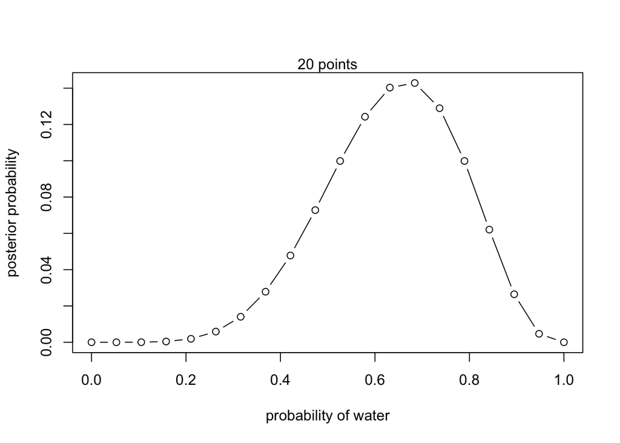

```r
# define grid
p_grid <- seq( from=0 , to=1 , length.out=20 )

# define prior
prior <- rep( 1 , 20 )

# compute likelihood at each value in grid
likelihood <- dbinom( 6 , size=9 , prob=p_grid )

# compute product of likelihood and prior
unstd.posterior <- likelihood * prior

# standardize the posterior, so it sums to 1
posterior <- unstd.posterior / sum(unstd.posterior)

# Display the posterior distribution

plot( p_grid , posterior , type="b" ,
    xlab="probability of water" , ylab="posterior probability" )
mtext( "20 points" )
```

$~$

*Try with a 5-point grid*

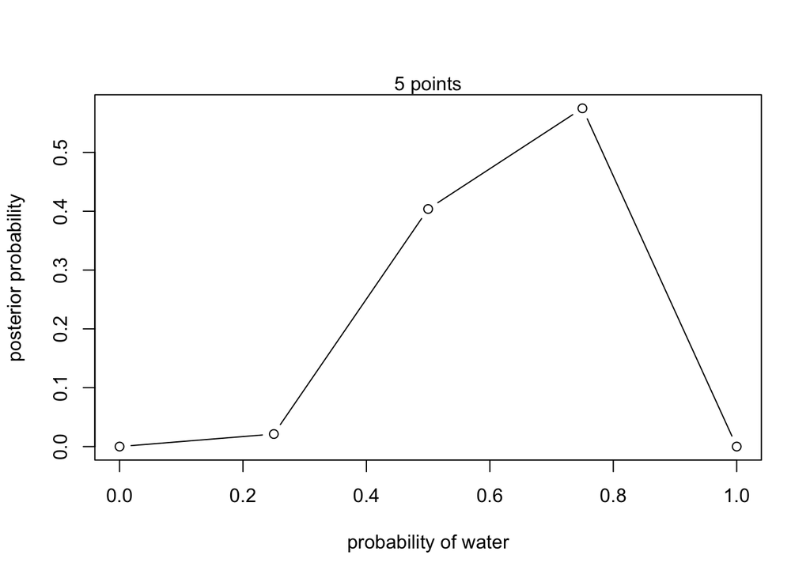

```r
# define grid

p_grid <- seq(from = 0, to = 1, length.out = 5)

# define prior

prior <- rep(1, 5) # 1 form a uniform prior distribution, assigning equal probability to each value in the grid. Using a decimal here will mean the same but may assume less degree of uncertainty?

# compute likelihood at each value in the grid

likelihood <- dbinom(6, size = 9, prob = p_grid)

# compute product of likelihood and prior

unstd.posterior <- likelihood * prior

# standardize the posterior, so it sums to 1

std.posterior <- unstd.posterior / sum(unstd.posterior)

# plot the posterior distribution

plot(p_grid, std.posterior, type = "b",
     xlab = "probability of water", ylab = "posterior probability")
mtext("5 points")
```

$~$

*Try with a 100-point grid*

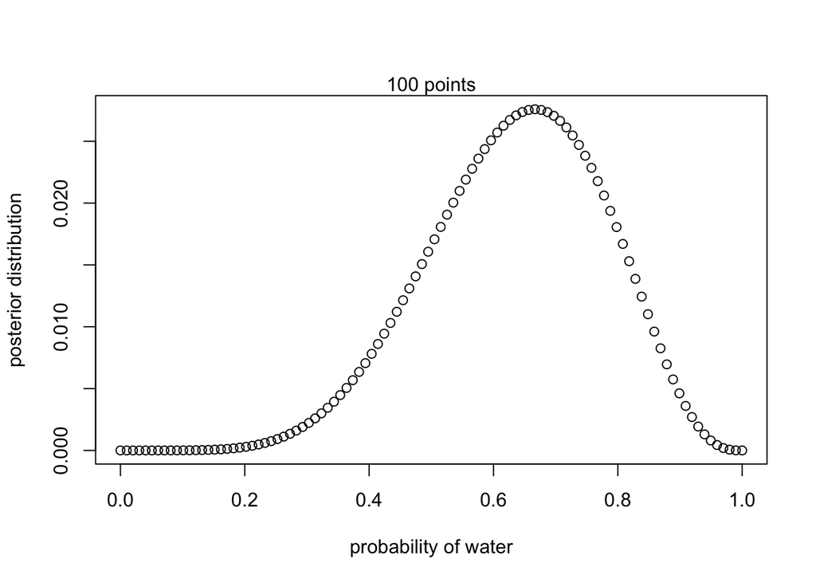

```r
# define a grid

p_grid <- seq(from = 0, to = 1, length.out = 100)

# define a prior

prior <- rep(1, 100)

# compute likelihood at each value in grid

likelihood <- dbinom(6, size = 9, prob = p_grid)

# compute the unstandardized posterior

unstd.posterior <- likelihood * prior

# standardize the posterior

posterior <- unstd.posterior / sum(unstd.posterior)

# plot the posterior

plot(p_grid, posterior, type = "b",
     xlab = "probability of water", ylab = "posterior distribution")
mtext("100 points")
```

*In this simple example, you can go crazy and use 100,000 points, but there won’t be much change in inference after the first 100.*

$~$

*Try with a step prior*

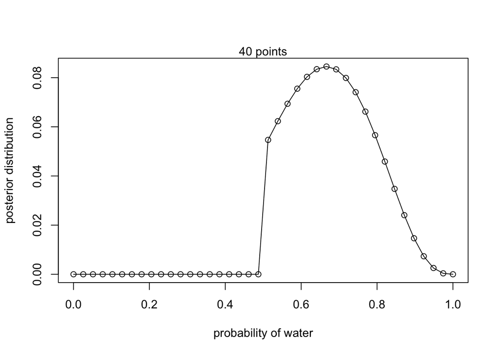

```r
# define a grid

p_grid <- seq(from = 0, to = 1, length.out = 40)

# define a prior

prior <- ifelse(p_grid < 0.5, 0, 1) #ifelse(test, yes, no)

# calculate the likelihood

likelihood <- dbinom(6, size = 9, prob = p_grid)

# calculate unstandardized posterior

unstd.posterior <- likelihood * prior

# standardize the posterior

posterior <- unstd.posterior / sum(unstd.posterior)

# plot the posterior

plot(p_grid, posterior, type = "o",
     xlab = "probability of water", ylab = "posterior distribution")
mtext("40 points")
```

$~$

*Try with a peaked prior*

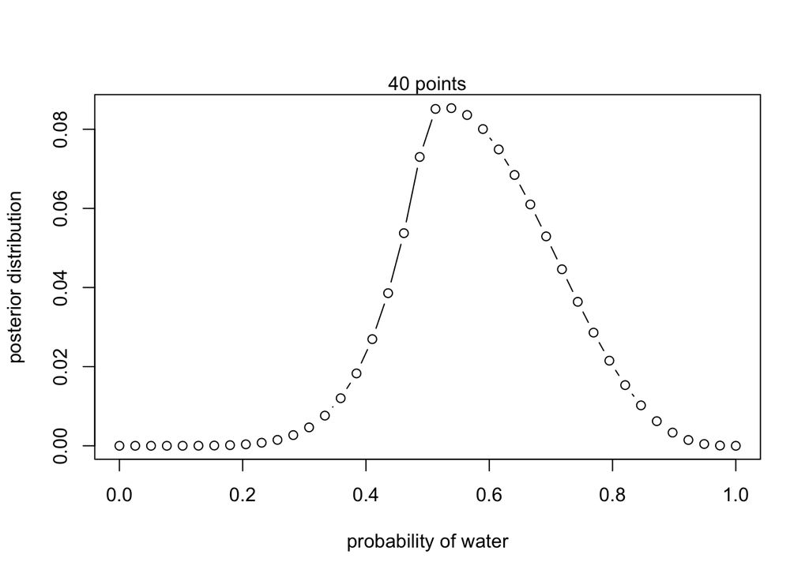

```r
# define a grid

p_grid <- seq(from = 0, to = 1, length.out = 40)

# define a prior

prior <- exp(-5*abs(p_grid - 0.5))

# calculate the likelihood

likelihood <- dbinom(6, size = 9, prob = p_grid)

# calculate unstandardised posterior

unstd.posterior <- likelihood * prior

# standardize the posterior

posterior <- unstd.posterior / sum(unstd.posterior)

# plot the posterior distribution

plot(p_grid, posterior, type = "b",
     xlab = "probability of water", ylab = "posterior distribution")
mtext("40 points")
```

$~$

### 3.4.2 Quadratic approximation

Under quite general conditions, the region near the peak of the posterior distribution will be nearly Gaussian—or “normal”—in shape. This means the posterior distribution can be usefully approximated by a Gaussian distribution. A Gaussian distribution is convenient, because it can be completely described by only two numbers: the location of its center (mean) and its spread (variance).

A Gaussian approximation is called “quadratic approximation” because the logarithm of a Gaussian distribution forms a parabola. And a parabola is a quadratic function. So this approximation essentially represents any log-posterior with a parabola.

The procedure to carry out quadratic approximation in R contains two steps:

1. Find the posterior mode. This is usually accomplished by some optimization algorithm, a procedure that virtually “climbs” the posterior distribution, as if it were a mountain. The golem doesn’t know where the peak is, but it does know the slope under its feet. There are many well-developed optimization procedures, most of them more clever than simple hill climbing. But all of them try to find peaks.
2. Once you find the peak of the posterior, you must estimate the curvature near the peak. This curvature is sufficient to compute a quadratic approximation of the entire posterior distribution. In some cases, these calculations can be done analytically, but usually your computer uses some numerical technique instead.

*Compute the quadratic approximation to the globe tossing data*

```r
library(rethinking)

globe.qa <- map(           #  map is maximum a posteriori- the mode of the posterior distribution
    alist(
        w ~ dbinom(9,p) ,  # binomial likelihood
        p ~ dunif(0,1)     # uniform prior
), data=list(w=6) )

# display summary of quadratic approximation
precis( globe.qa )
```

```
##       mean        sd     5.5%    94.5%
## p 0.666667 0.1571337 0.415537 0.917797
```

*To use map, you provide a formula, a list of data, and a list of start values for the parameters. The formula defines the likelihood and prior.*

The function precis presents a brief summary of the quadratic approximation. In this case, it shows a MAP value of p = 0.67, which it calls the “Mean.” The curvature is labeled “Std- Dev” This stands for standard deviation. This value is the standard deviation of the posterior distribution, while the mean value is its peak. Finally, the last two values in the precis output show the 89% percentile interval. You can read this kind of approximation like: Assuming the posterior is Gaussian, it is maximized at 0.67, and its standard deviation is 0.16.

Since we already know the posterior, let’s compare to see how good the approximation is. I’ll use the analytical approach here, which uses dbeta.

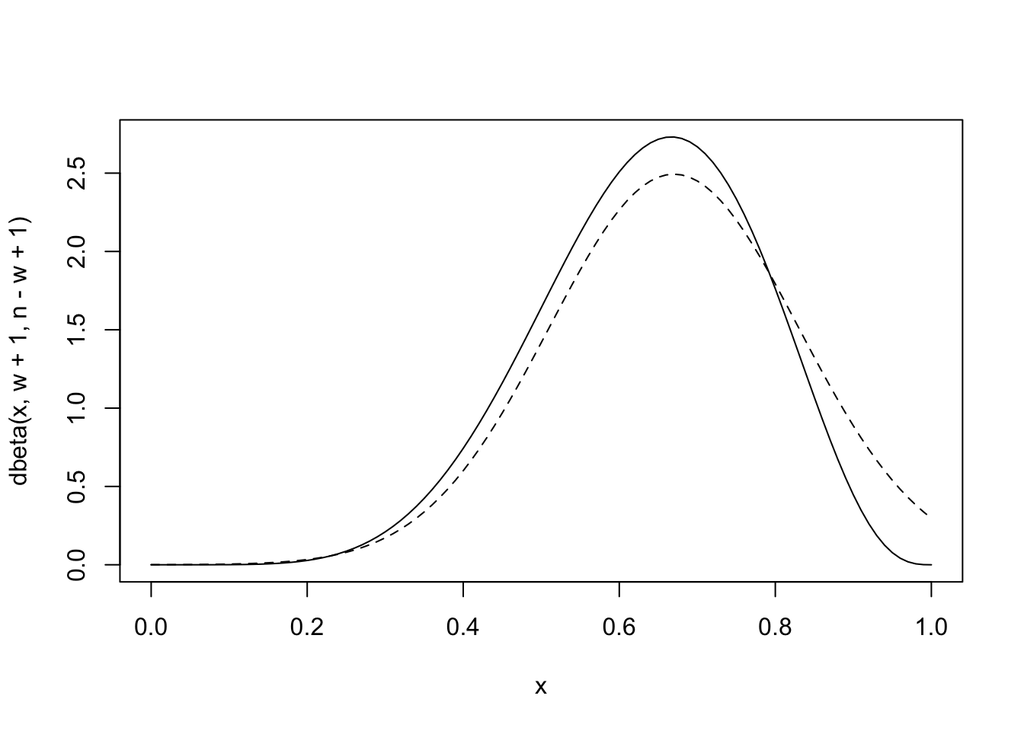

```r
# analytical calculation
w <- 6
n <- 9
curve( dbeta( x , w+1 , n-w+1 ) , from=0 , to=1 )
# Use Laplace's rule of succession- add one to both w and n-w to avoid assigning zero probability,
# ensure at least there's one w and one n-w, even if none have been observed yet

# quadratic approximation
curve( dnorm( x , 0.67 , 0.16 ) , lty=2 , add=TRUE )
```

*Double the sample size*

```r
library(rethinking)

globe.qa1 <- map(           #  map is maximum a posteriori- the mode of the posterior distribution
    alist(
        w ~ dbinom(18,p) ,  # binomial likelihood
        p ~ dunif(0,1)     # uniform prior
), data=list(w=12) )

# display summary of quadratic approximation
precis( globe.qa1 )
```

```
##        mean        sd      5.5%     94.5%
## p 0.6666667 0.1111104 0.4890909 0.8442425
```

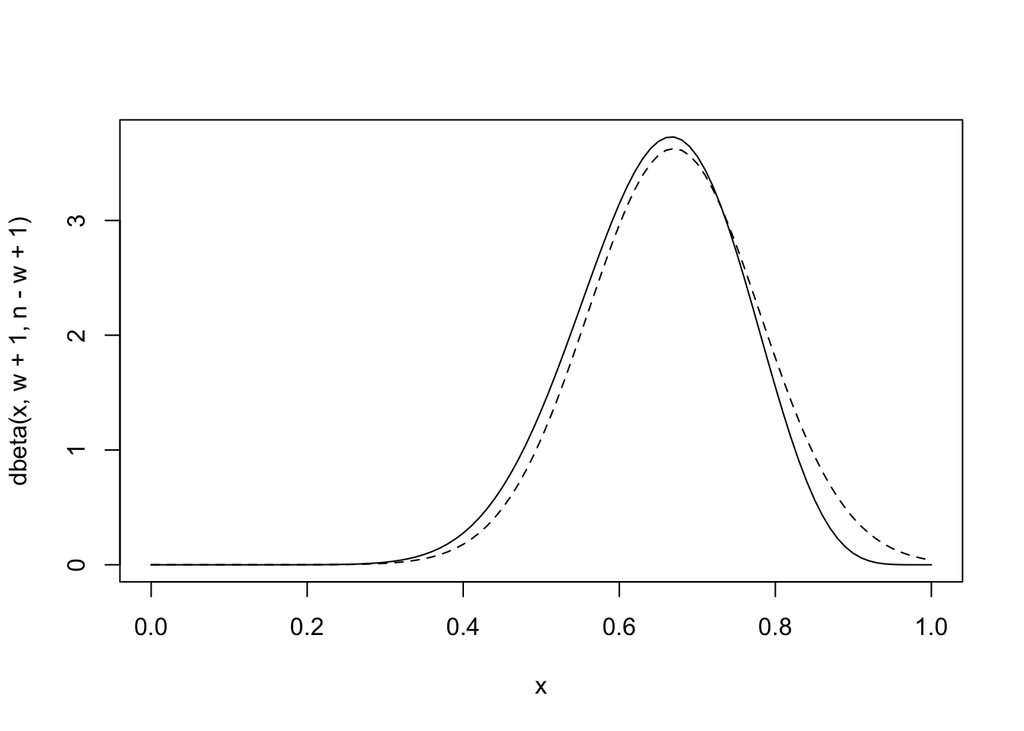

```r
# analytical calculation
w <- 12
n <- 18
curve( dbeta( x , w+1 , n-w+1 ) , from=0 , to=1 )

# quadratic approximation
curve( dnorm( x , 0.67 , 0.11 ) , lty=2 , add=TRUE )
```

*Quadruple the sample size*

```r
library(rethinking)

globe.qa2 <- map(           #  map is maximum a posteriori- the mode of the posterior distribution
    alist(
        w ~ dbinom(36,p) ,  # binomial likelihood
        p ~ dunif(0,1)     # uniform prior
), data=list(w=24) )

# display summary of quadratic approximation
precis( globe.qa2 )
```

```
##       mean         sd     5.5%     94.5%
## p 0.666662 0.07856744 0.541096 0.7922279
```

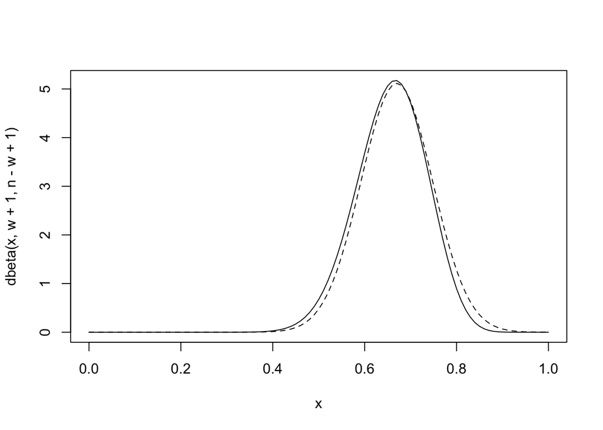

```r
# analytical calculation
w <- 24
n <- 36
curve( dbeta( x , w+1 , n-w+1 ) , from=0 , to=1 )

# quadratic approximation
curve( dnorm( x , 0.67 , 0.078 ) , lty=2 , add=TRUE )
```

This phenomenon, where the quadratic approximation improves with the amount of data, is very common. It’s one of the reasons that so many classical statistical procedures are nervous about small samples: Those procedures use quadratic (or other) approximations that are only known to be safe with infinite data. Often, these approximations are useful with less than infinite data, obviously. But the rate of improvement as sample size increases varies greatly depending upon the details. In some model types, the quadratic approximation can remain terrible even with thousands of samples.

*Maximum likelihood estimation:* The quadratic approximation, either with a uniform prior or with a lot of data, is usually equivalent to a maximum likelihood estimate (MLE) and its standard error. The MLE is a very common non-Bayesian parameter estimate. This equivalence between a Bayesian approximation and a common non-Bayesian estimator is both a blessing and a curse. It is a blessing, because it allows us to re-interpret a wide range of published non-Bayesian model fits in Bayesian terms. It is a curse, because maximum likelihood estimates have some curious drawbacks.

$~$

### 3.4.3 Markov chain Monte Carlo

The conceptual challenge with MCMC lies in its highly non-obvious strategy. Instead of attempting to compute or approximate the posterior distribution directly, MCMC techniques merely draw samples from the posterior. You end up with a collection of parameter values, and the frequencies of these values correspond to the posterior plausibilities. You can then build a picture of the posterior from the histogram of these samples.

We nearly always work directly with these samples, rather than first constructing some mathematical estimate from them. And the samples are in many ways more convenient than having the posterior, because they are easier to think with.

$~$

## 3.5 Practice

### 3.5.1 Easy

2E1. (2), (4)

2E2. (3)

2E3. (1), (4)

2E4. In the context of the globe tossing example, “the probability of water is 0.7” means we estimates there is 70% chance of landing on water in the next toss, based on the observed data (the previous tosses). We may as well say 70% of the earth is water. This is a probability, but the “probability does not exist-” our best guess is 70% of earth is water based on previously observed data, but it may or may not reflect reality. If the next toss fell on land, the probability of water would be less than 70% for the subsequent toss. We can get a consistent probability of water after enough tosses, but we cannot say for sure this is the actual distribution of water on earth. Therefore, it remains as a probability. Once we have a concrete measurement of actual percentage of earth covered by water, it becomes an objective reality- a factual statement. At that point, the need for probability ceases.

$~$

### 3.5.2 Medium

2M1.

*(1) W, W, W*

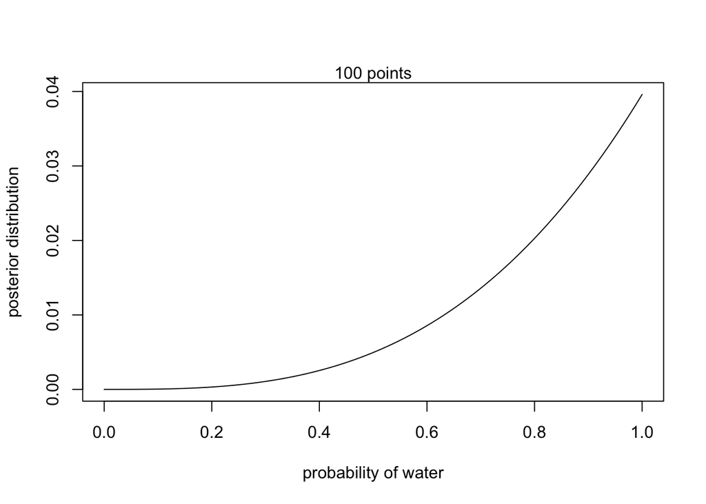

```r
# define a grid

p_grid <- seq(from = 0, to = 1, length.out = 100)
# choose 100 coz chapter says not much difference after 100

# define a uniform prior

prior <- rep(1, 100)

# calculate likelihood

likelihood <- dbinom(3, size = 3, prob = p_grid)

# calculate unstandardized posterior

unstd.posterior <- likelihood * prior

# standardize the posterior

posterior <- unstd.posterior / sum(unstd.posterior)

# plot the posterior distribution

plot(p_grid, posterior, type = "l",
    xlab = "probability of water", ylab = "posterior distribution")
  mtext("100 points")
```

$~$

*(2) W, W, W, L*

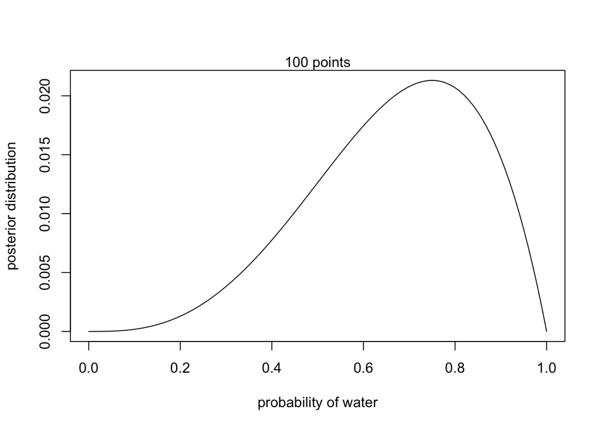

```r
# define a grid

p_grid <- seq(from = 0, to = 1, length.out = 100)

# define a uniform prior

prior <- rep(1, 100)

# calculate likelihood

likelihood <- dbinom(3, size = 4, prob = p_grid)

# calculate unstandardized posterior

unstd.posterior <- likelihood * prior

# standardize the posterior

posterior <- unstd.posterior / sum(unstd.posterior)

# plot the posterior distribution

plot(p_grid, posterior, type = "l",
    xlab = "probability of water", ylab = "posterior distribution")
  mtext("100 points")
```

$~$

*(3) L, W, W, L, W, W, W*

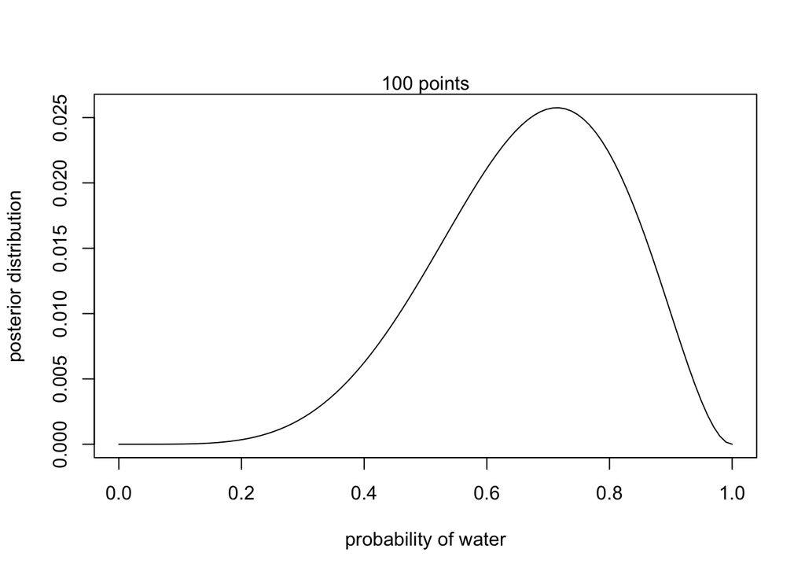

```r
# define a grid

p_grid <- seq(from = 0, to = 1, length.out = 100)

# define a uniform prior

prior <- rep(1, 100)

# calculate likelihood

likelihood <- dbinom(5, size = 7, prob = p_grid)

# calculate unstandardized posterior

unstd.posterior <- likelihood * prior

# standardize the posterior

posterior <- unstd.posterior / sum(unstd.posterior)

# plot the posterior distribution

plot(p_grid, posterior, type = "l",
    xlab = "probability of water", ylab = "posterior distribution")
  mtext("100 points")
```

$~$

2M2. Assume a prior for p that is equal to zero when p < 0.5 and is a positive constant when p ≥ 0.5.

*(1) W, W, W*

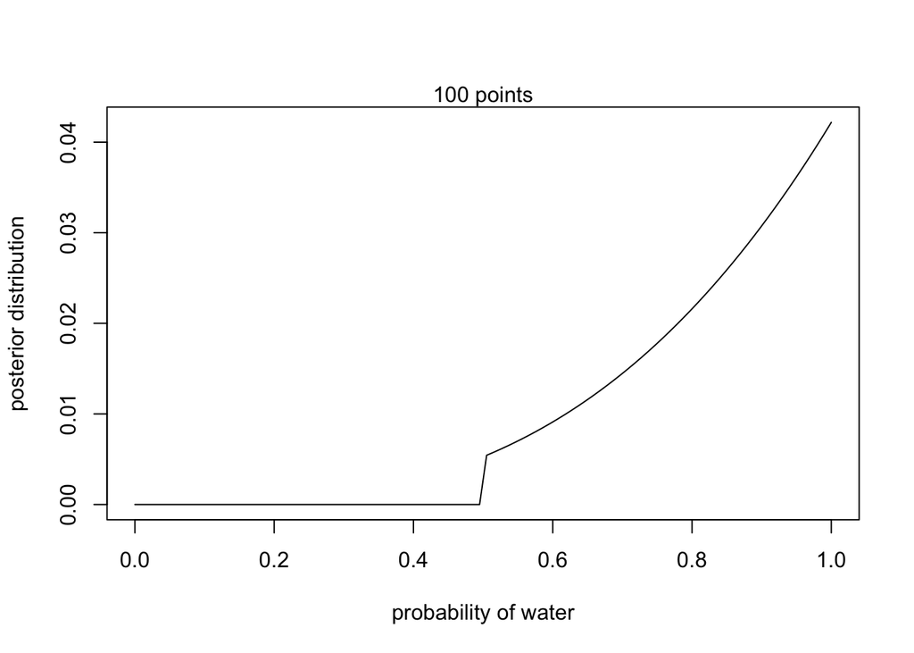

```r
# define a grid

p_grid <- seq(from = 0, to = 1, length.out = 100)

# define a  prior

prior <- ifelse(p_grid < 0.5, 0, 1)

# calculate likelihood

likelihood <- dbinom(3, size = 3, prob = p_grid)

# calculate unstandardized posterior

unstd.posterior <- likelihood * prior

# standardize the posterior

posterior <- unstd.posterior / sum(unstd.posterior)

# plot the posterior distribution

plot(p_grid, posterior, type = "l",
    xlab = "probability of water", ylab = "posterior distribution")
  mtext("100 points")
```

$~$

*(2) W, W, W, L*

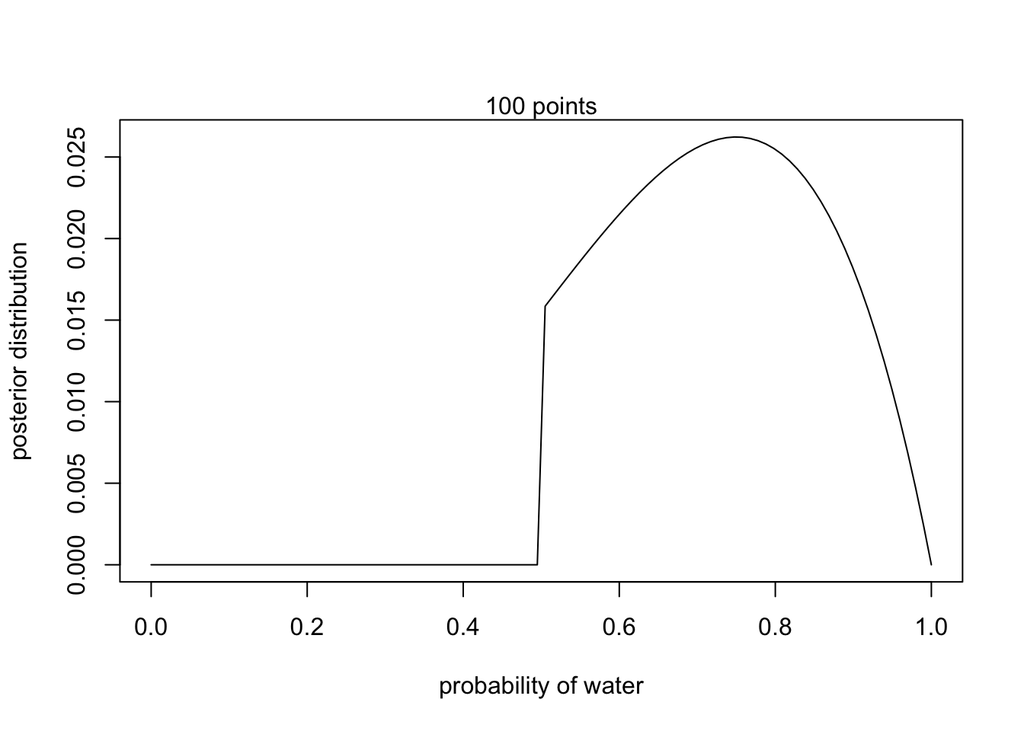

```r
# define a grid

p_grid <- seq(from = 0, to = 1, length.out = 100)

# define a prior

prior <- ifelse(p_grid < 0.5, 0, 1)

# calculate likelihood

likelihood <- dbinom(3, size = 4, prob = p_grid)

# calculate unstandardized posterior

unstd.posterior <- likelihood * prior

# standardize the posterior

posterior <- unstd.posterior / sum(unstd.posterior)

# plot the posterior distribution

plot(p_grid, posterior, type = "l",
    xlab = "probability of water", ylab = "posterior distribution")
  mtext("100 points")
```

$~$

*(3) L, W, W, L, W, W, W*

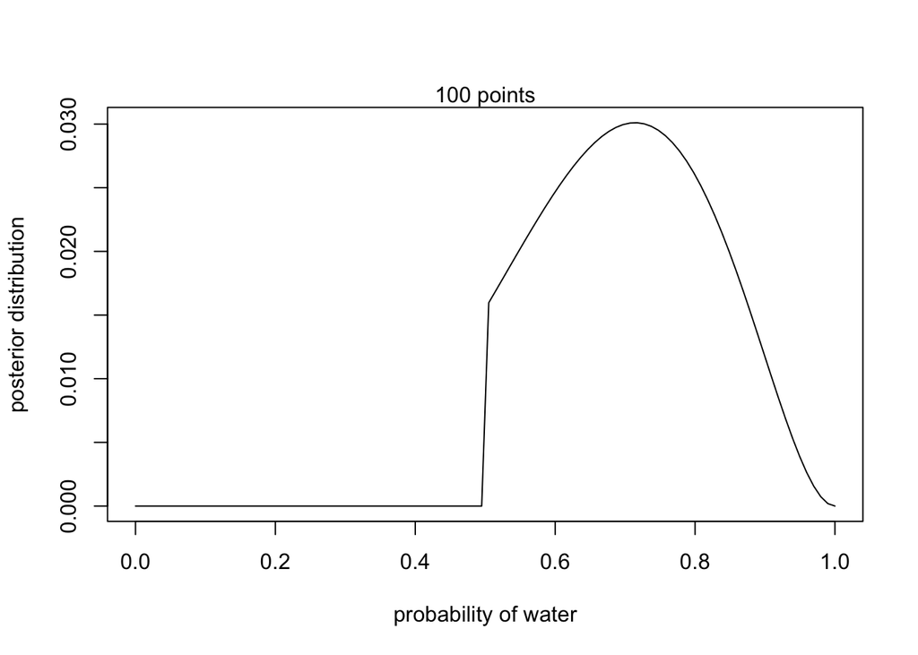

```r
# define a grid

p_grid <- seq(from = 0, to = 1, length.out = 100)

# define a prior

prior <- ifelse(p_grid < 0.5, 0, 1)

# calculate likelihood

likelihood <- dbinom(5, size = 7, prob = p_grid)

# calculate unstandardized posterior

unstd.posterior <- likelihood * prior

# standardize the posterior

posterior <- unstd.posterior / sum(unstd.posterior)

# plot the posterior distribution

plot(p_grid, posterior, type = "l",
    xlab = "probability of water", ylab = "posterior distribution")
  mtext("100 points")
```

$~$

2M3. Suppose there are two globes, one for Earth and one for Mars. The Earth globe is 70% covered in water. The Mars globe is 100% land. Further suppose that one of these globes—you don’t know which—was tossed in the air and produced a “land” observation. Assume that each globe was equally likely to be tossed. Show that the posterior probability that the globe was the Earth, conditional on seeing “land” (Pr(Earth|land)), is 0.23.

```
# Probability land on earth, given that 70% of earth is water
Pr(land|earth) = 0.3

# Probability of land on mars
Pr(land|mars) = 1

# Probability that earth is tossed
Pr(earth) = 0.5

# Probability that mars is tossed
Pr(mars) = 0.5

# Probability that it is both land and earth
Pr(land, earth) = Pr(land|earth) * Pr(earth)
                = 0.3 * 0.5
                = 0.15

# Probability that it is both land and mars
Pr(land, mars) = Pr(land|mars) * Pr(mars)
               = 1 * 0.5
               = 0.5

# Total probability of land in all possible scenarios (both on earth and mars)
Pr(land) = Pr(land, earth) + Pr(land, mars)
         = 0.15 + 0.5
         = 0.65

# Find the probability of earth, conditional on seeing land
Pr(earth|land) = (Pr(land|earth) * Pr(earth))/ Pr(land)
               = (0.3 * 0.5)/ 0.65
               = 0.2307692
```

$~$

2M4. Suppose you have a deck with only three cards. Each card has two sides, and each side is either black or white. One card has two black sides. The second card has one black and one white side. The third card has two white sides. Now suppose all three cards are placed in a bag and shuffled. Someone reaches into the bag and pulls out a card and places it flat on a table. A black side is shown facing up, but you don’t know the color of the side facing down. Show that the probability that the other side is also black is 2/3. Use the counting method (Section 2 of the chapter) to approach this problem. This means counting up the ways that each card could produce the observed data (a black side facing up on the table).

```
# First card has two black sides
C1 <- b,b

# Second card has one black and one white side
C2 <- b,w

# Third card has two white sides
C3 <- w,w

# Possible conjectures
conjectures <- (b,b), (b,w), (w,w)

# One card is drawn with black side facing up
data <- b

# Count the possible ways to have the observe data for each conjecture (data: b)
(b,b) -> 2
(b,w) -> 1
(w,w) -> 0
total ways to see a black side up -> 3

# Count the possible ways that the other side is also black (data: b,b)
(b,b) -> 2 x 1 -> 2
(b,w) -> 1 x 0 -> 0
(w,w) -> 0 x 0 -> 0
total ways to see another side also black -> 2

# Possible ways to get both side black
(b,b) -> total ways to see another side also black / total ways to see a black side up
      -> 2/3

But, the question asks to "show that the probability that the other side is also black is 2/3."
So, we need to find the probability. The question asks for a card with both sides black.
Only one out of the three cards is black on both sides. In this case, the probability of getting
a card that is black on both sides is 1/3. But, the question mentions we already have a black
side up. So, the probability of having the other black side after having one black side is 1/2,
because two cards can give an initial black side but only one card can give another black side.

Thus, it is impossible to have 2/3 as a probability of having a card with both black sides.
Or Does the question ask for the probability of counts, that isn't equal to the probability of having
another black side after initial black side?
```

*If we calculate probability as shown in chapter 2*

```r
ways <- c(2, 0, 0)
ways/ sum(ways)
```

```
## [1] 1 0 0
```

```r
# In this case, the probability is 1 (100%) for the first card, while the other
# two cards are impossible to give a card that is black on both sides.
```

$~$

2M5. Now suppose there are four cards: B/B, B/W, W/W, and another B/B. Again suppose a card is drawn from the bag and a black side appears face up. Again calculate the probability that the other side is black.

```
# Possible conjectures
conjectures: (B/B), (B/W), (W/W), (B/B)

# First observation
data: B

# Possible ways to get the observed data for each conjecture
(B/B) -> 2
(B/W) -> 1
(W/W) -> 0
(B/B) -> 2
Total ways to get initial black side -> 5

# Probability to see black on second observation (data: B/B)
(B/B) -> 2 x 1 = 2
(B/W) -> 1 x 0 = 0
(W/W) -> 0 x 0 = 0
(B/B) -> 2 x 1 = 2
Total ways to get another black side -> 4

Hence, the probability of getting a card with both sides black by counting method is 4/5.
```

$~$

2M6. Imagine that black ink is heavy, and so cards with black sides are heavier than cards with white sides. As a result, it’s less likely that a card with black sides is pulled from the bag. So again assume there are three cards: B/B, B/W, and W/W. After experimenting a number of times, you conclude that for every way to pull the B/B card from the bag, there are 2 ways to pull the B/W card and 3 ways to pull the W/W card. Again suppose that a card is pulled and a black side appears face up. Show that the probability the other side is black is now 0.5. Use the counting method, as before.

```
# Possible conjectures
conjectures : (B/B), (B/W), (W/W)

# New information
Pr(B/B) < Pr(B/W) < Pr(W/W)
1 (B/B) = 2 (B/W) + 3 (W/W)

# Likelihood of drawing each card
(B/B) -> 1
(B/W) -> 2
(W/W) -> 3

# Count the possible ways to get data (B)
(B/B) -> 2 x 1 = 2
(B/W) -> 1 x 2 = 2
(W/W) -> 0 x 3 = 0
Total counts of way to get initial B = 4

# Count the possible ways to get data (B/B)
(B/B) -> 2 x 1 = 2
(B/W) -> 2 x 0 = 0
(W/W) -> 0 x 0 = 0
Total counts of way to get B/B = 2

Probability the other side is also black = 2/4 = 0.5
```

$~$

2M7. Assume again the original card problem, with a single card showing a black side face up.Before looking at the other side, we draw another card from the bag and lay it face up on the table. The face that is shown on the new card is white. Show that the probability that the first card, the one showing a black side, has black on its other side is now 0.75. Use the counting method, if you can. Hint: Treat this like the sequence of globe tosses, counting all the ways to see each observation, for each possible first card.

```
# Possible conjectures
conjectures: (B/B), (B/W), (W/W)

# Count the possible ways to get data (B)
(B/B) -> 2
(B/W) -> 1
(W/W) -> 0

# Count the possible ways to get data (W)
(B/B) -> 0
(B/W) -> 1
(W/W) -> 2

# Count the possible ways to get data (B/x, W/x)
(B/B) , (B/W) -> 2 x 1 = 2
(B/B) , (W/W) -> 2 x 2 = 4
(B/W) , (B/B) -> 1 x 0 = 0
(B/W) , (W/W) -> 1 x 2 = 2
Total counts of ways to get data (B/x, W/x) = 8

# Count the possible ways to get data (B/B, W/x)
(B/B) , (B/W) -> 2 x 1 = 2
(B/B) , (W/W) -> 4 x 1 = 4
(B/W) , (B/B) -> 0 x 0 = 0
(B/W) , (W/W) -> 2 x 0 = 0
Total counts of ways to get data (B/B, W/x) = 6

Probability that the first card has both black sides = 6/8 = 0.75
```

$~$

### 3.5.3 Hard

2H1. Suppose there are two species of panda bear. Both are equally common in the wild and live in the same places. They look exactly alike and eat the same food, and there is yet no genetic assay capable of telling them apart. They differ however in their family sizes. Species A gives birth to twins 10% of the time, otherwise birthing a single infant. Species B births twins 20% of the time, otherwise birthing singleton infants. Assume these numbers are known with certainty, from many years of field research. Now suppose you are managing a captive panda breeding program. You have a new female panda of unknown species, and she has just given birth to twins. What is the probability that her next birth will also be twins?

```
# Probability of species A gives birth to twins
Pr(twin|SpA) = 0.1

# Probability of species B gives birth to twins
Pr(twin|SpB) = 0.2

# Probability that the new female panda belongs to species A or species B
Pr(SpA) = 0.5
Pr(SpB) = 0.5

# Total probability of having twins (average likelihood)
Pr(twins) = (Pr(twins|SpA) * Pr(SpA)) + (Pr(twins|SpB) * Pr(SpB))
          = (0.1 * 0.5) + (0.2 * 0.5)
          = 0.15

# Total probability of having two set of twins (average likelihood)
Pr(2twins) = (Pr(2twins|SpA) * Pr(SpA)) + (Pr(2twins|SpB) * Pr(SpB))
          = (0.01 * 0.5) + (0.04 * 0.5)
          = 0.025

# Probability of having another set of twins given that the first set is twin, regardless of species
Pr (second_twins|first_twins) = Pr(first_twins, second_twins)/ Pr(twins)
                              = Pr(2twins)/ Pr(twins)
                              = 0.025/ 0.15
                              = 0.1666667
```

$~$

2H2. Recall all the facts from the problem above. Now compute the probability that the panda we have is from species A, assuming we have observed only the first birth and that it was twins.

```
# Probability of panda from species A giving birth to twins
Pr(twins|SpA) = 0.1
Pr(twin|SpB)  = 0.2

# Probability that the new female panda belongs to species A or species B
Pr(SpA) = 0.5
Pr(SpB) = 0.5

# Total probability of having twins (average likelihood)
Pr(twins) = (Pr(twins|SpA) * Pr(SpA)) + (Pr(twins|SpB) * Pr(SpB))
          = (0.1 * 0.5) + (0.2 * 0.5)
          = 0.15

# Probability that panda is from species A after observing first birth of twins
Pr(SpA|twins) = (Pr(twins|SpA) * Pr(SpA))/ Pr(twins)
              = (0.1 * 0.5)/ 0.15
              = 0.3333333
```

$~$

2H3. Continuing on from the previous problem, suppose the same panda mother has a second birth and that it is not twins, but a singleton infant. Compute the posterior probability that this panda is species A.

```
# Probability that the new female panda belongs to species A or species B
Pr(SpA) = 0.5
Pr(SpB) = 0.5

# Probability of panda from species A and B giving birth to twins
Pr(twins|SpA) = 0.1
Pr(twin|SpB)  = 0.2

# Probability of panda from species A and B giving birth to singleton
Pr(singleton|SpA) = 0.9
Pr(singleton|SpB) = 0.8

# Probability of panda from species A and B having a twin and a singleton
Pr(singleton, twins|SpA) = 0.1 * 0.9 = 0.09
Pr(singleton, twins|SpB) = 0.2 * 0.8 = 0.16

# Total probability of having a twin and a singleton (average likelihood)
Pr(singleton, twins) = (Pr(singleton, twins|SpA) * Pr(SpA)) + (Pr(singleton, twins|SpB) * Pr(SpB))
                     = (0.09 * 0.5) + (0.16 * 0.5)
                     = 0.125

# Probability that the new panda is from species A given the birth of a singleton and a twins
Pr(SpA|sigleton, twins) = (Pr(singleton, twins|SpA) * Pr(SpA))/ Pr(singleton, twins)
                        = (0.09 * 0.5)/ 0.125
                        = 0.36

OR

# Probability of the new panda is from species A or B after the first birth of twins
Pr(SpA) = 0.33
Pr(SpB) = 0.67

# Probability of panda from species A and B giving birth to singleton
Pr(singleton|SpA) = 0.9
Pr(singleton|SpB) = 0.8

# Total probability of having singleton after the first birth of twins (average likelihood)
Pr(singleton) = (Pr(singleton|SpA) * Pr(SpA)) + (Pr(singleton|SpB) * Pr(SpB))
              = (0.9 * 0.33) + (0.8 * 0.67)
              = 0.833

# Probability that the new panda is from species A given the second birth of a singleton
Pr(SpA|singleton) = (Pr(singleton|SpA) * Pr(SpA))/ Pr(singleton)
                  = (0.9 * 0.33)/ 0.833
                  = 0.3565426
```

$~$

2H4. A common boast of Bayesian statisticians is that Bayesian inference makes it easy to use all of the data, even if the data are of different types. So suppose now that a veterinarian comes along who has a new genetic test that she claims can identify the species of our mother panda. But the test, like all tests, is imperfect. This is the information you have about the test: • The probability it correctly identifies a species A panda is 0.8. • The probability it correctly identifies a species B panda is 0.65. The vet administers the test to your panda and tells you that the test is positive for species A. First ignore your previous information from the births and compute the posterior probability that your panda is species A. Then redo your calculation, now using the birth data as well.

```
# Without using birth data
# Initital probability of speacies A and B
Pr(SpA) = 0.5
Pr(SpB) = 0.5

# Probability that the test correctly identifies a species A or B panda
Pr(correct_A|SpA) = 0.8
Pr(correct_B|SpB) = 0.65

# Probability that the test wrongly identifies a species A or B panda
Pr(wrong_A|SpA) = 0.2
Pr(wrong_B|SpB) = 0.35

# Total probability that the test correctly identifies species A (average likelihood)
Pr(correct_A) = (Pr(correct_A|SpA) * Pr(SpA)) + (Pr(wrong_B|SpB) * Pr(SpB))
              = (0.8 * 0.5) + (0.35 * 0.5)
              = 0.575

# Probability that the panda is from species A, given the correct test result
Pr(SpA|correct_A) = (Pr(correct_A|SpA) * Pr(SpA))/ Pr(correct_A)
                  = (0.8 * 0.5)/ 0.575
                  = 0.6956522

# Using birth data
# Probability that the test correctly identifies a species A or B panda
Pr(correct_A|SpA) = 0.8
Pr(correct_B|SpB) = 0.65

# Probability that the test wrongly identifies a species A or B panda
Pr(wrong_A|SpA) = 0.2
Pr(wrong_B|SpB) = 0.35

# Prior probability of species A and B
Pr(SpA) = 0.36
Pr(SpB) = 0.64

# Total probability that the test correctly identifies species A (average likelihood)
Pr(correct_A) = (Pr(correct_A|SpA) * Pr(SpA)) + (Pr(wrong_B|SpB) * Pr(SpB))
              = (0.8 * 0.36) + (0.35 * 0.64)
              = 0.512

# Probability that the panda is from species A, given the test result
Pr(SpA|correct_A) = (Pr(correct_A|SpA) * Pr(SpA))/ Pr(correct_A)
                  = (0.8 * 0.36)/ 0.512
                  = 0.5625
```

$~$

# 4 Chapter 3: Sampling the Imaginary

$~$

## 4.1 Sampling from a grid-approximate posterior

**Compute the posterior for the globe tossing model, using grid approximation**

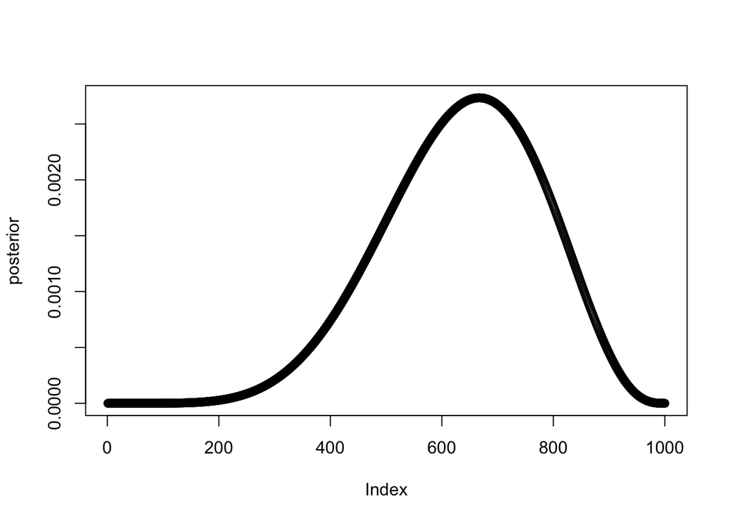

```r
p_grid <- seq(from = 0, to = 1, length.out = 1000)

prior <- rep(1, 1000)

likelihood <- dbinom(6, size = 9, prob = p_grid)

posterior <- likelihood * prior

posterior <- posterior/ sum(posterior)

plot(posterior)
```

**Draw the samples**

Now we wish to draw 10,000 samples from this posterior. Imagine the posterior is a bucket full of parameter values, numbers such as 0.1, 0.7, 0.5, 1, etc. Within the bucket, each value exists in proportion to its posterior probability, such that values near the peak are much more common than those in the tails. We’re going to scoop out 10,000 values from the bucket. Provided the bucket is well mixed, the resulting samples will have the same proportions as the exact posterior density. Therefore the individual values of p will appear in our samples in proportion to the posterior plausibility of each value.

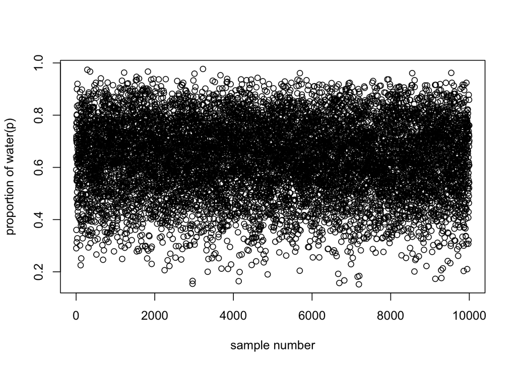

```r
samples <- sample(p_grid, prob = posterior, size = 1e4, replace = TRUE)
plot(samples, xlab="sample number", ylab="proportion of water(p)")
```

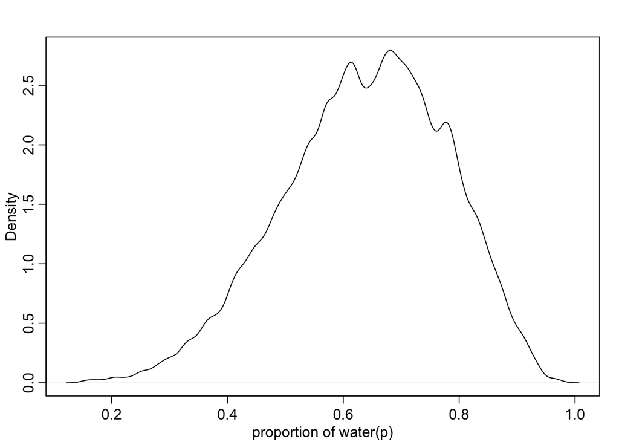

```r
# The workhorse here is sample, which randomly pulls values from a vector.
# The vector in this case is p_grid, the grid of parameter values.
# The probability of each value is given by posterior, which you computed just above.

dens(samples, xlab= "proportion of water(p)", ylab= "Density")
```